# Foundations of ML: Problem Set 1

Submitted by C. Noah Schneiders

# Problem 1

In the first problem we show the optimality of shrinkage in estimation, especially in higher dimensions. For that, we consider 5 different estimators in 3 different dimensions for a range of different vector norms of the parameter of interest. The skrinkage estimators trade off bias and variance, introducing bias relative to the MLE but bringing about large decreases in variance, hence overall reductions in MSE. Especially in higher dimensions skrinkage estimators lead to lower risk relative to the MLE, which was the gold standard before introduction of shrinkage estimators in the 1960s. The discussion of the first problem will be structured as follows:

1. Estimators & Properties
   1. MLE
   2. Pre-JS
   3. James-Stein
   4. Positive part JS
   5. Alternative JS
2. Coding approach
3. Results & Discussion

## 1. Estimators & Properties

### 1. MLE

The MLE is the canonical estimator
$$\hat{\theta}^{MLE} = \textbf{X}$$
The MLE is unbiased with $Var(\theta^{MLE}) = 1$ and dimension $|\theta| = k$. It thus features constant $MSE = E \left[ \left(\hat{\theta}^{MLE}-\theta \right)^2 \right] = k$. The MLE is the dominant estimator in low-dimensional, $k<3$, settings. In a shrinkage estimator setting, the MLE can be viewed as having shrinkage term $=1$. It is coded as follows:

```
MLE_theta_hat <- x
```

where $x = \theta + \epsilon$ is the $k \times 1$-dimensional vector of data in this code, or a tuple, more generally.

### 2. Pre-JS

The estimator
$$\hat{\theta}^{PreJS} = \left( 1 - 1/\overline{X^2} \right) \cdot \textbf{X}$$
is the James-Stein estimator without the degrees of freedom correction involving the dimension $k$ and called “PreJS” in this code. It shrinks the data towards $0$. The PreJS dominates the MLE in high dimensions because it causes a dimension reduction through shrinkage, introducing bias but reducing variance, hence causing a decrease in MSE risk. But, as the degrees of freedom correction in the JS estimator constitutes the optimal constant with which to multiply the shrinkage term, the PreJS will be dominated by JS. Furthermore, PreJS will dominate the MLE only in dimensions higher than $k=3$ at which the JS dominates the MLE. The PreJS is coded as follows:

```
PreJS_theta_hat <- (1 - (1 / (x2_bar))) * x
# where
x2_bar <- (1 / k) * sum(x^2)
```

where $\overline{X^2} = \frac{1}{k}\sum_{i}{X_{i}^2}$.

### 3. James-Stein

The James-Stein estimator
$$\hat{\theta}^{JS+} = \left( 1 - \frac{(k - 2)/k}{\overline{X^2}} \right) \cdot \textbf{X}$$
is the estimator shrinking to the grand mean with the optimal shrinkage factor $\frac{(k-2)/k}{\overline{X^2}}$. It dominates the MLE for dimensions $k \geq 3$ as it reduces risk due to an optimal dimension reduction, i.e. an optimal bias-risk trade-off, effective in these higher dimensions. It is abbreviated here as “JS” and coded as follows:

```
JS_theta_hat <- (1 - (((k - 2) / k) / (x2_bar))) * x
```

### 4. Positive part JS

The estimator
$$\hat{\theta}^{JS+} = max \left (0,1 - \frac{(k - 2)/k}{\overline{X^2}} \right) \cdot \textbf{X}$$
avoids the undesirable situation of having a negative shrinkage factor when $\sum_{i}{X_{i}^2}<k-2$ and hence dominates James-Stein. It is less analytically tractable because of the $max()$ function involved but mostly used in practice where this is not a concern. It is dubbed “PosJS” here and coded as follows:

```
PosJS_theta_hat <- max(0, (1 - ((k - 2) / k) / (x2_bar))) * x
```

### 5. Alternative JS

The estimator shrinking to the grand mean using the alternative optimal shrinkage factor $1 - \frac{(k - 3)/k}{s^{2}_{X}}$ is
$$\hat{\theta}^{AltJS} = \left(1 - \frac{(k - 3)/k}{s^{2}_{X}} \right) \cdot \textbf{X}$$
It is the estimator arrived at in class via the heuristic regression motivation for the JS estimator for a regression with intercept. The shrinkage here depends on how much signal, information on the parameter of interest, relative to noise, the error variance, we have (“signal-to-noise-ratio”). If the ratio is large you would not want to shrink a lot and vice versa. Intuitively, if the signal is strong relative to the noise, shrinking a lot would unfavourably introduce bias and increase MSE. The degrees of freedom correction here is also different to the before estimators involving only $\overline{X^2}$ because a higher moment, $s^{2}_{X}$, is involved. The estimator, here called “AltJS”, can be coded, rather messily, as either:

```
AltJS_theta_hat <- (1 - (((k - 3) / k) / (x2_bar - ((1 / k) * sum(x[,j]))^2))) * x
```

or:

```
AltJS_theta_hat <- (1 - (((k - 3) / k) / ((1 / k) * sum((x - ((1 / k) * sum(x)))^2)))) * x
```

## 2. Coding approach

First, set the number of simulations to 10,000 and define the increment size for $r = |\theta|$:

```r
n <- 10000
r_steps <- 100
```

Next, import a function to compress any vector to unit length and create a colour vector for plotting results later. (Code omitted for legibility.) Also, create an empty data frame “avg_loss” to hold the average scaled MSE losses ($\frac{1}{k} \cdot MSE$), which will be the output of interest:

```
##   i k    r MLE PreJS JS PosJS AltJS
## 1 1 2 0.00   0     0  0     0     0
## 2 2 2 0.01   0     0  0     0     0
## 3 3 2 0.02   0     0  0     0     0
## 4 4 2 0.03   0     0  0     0     0
## 5 5 2 0.04   0     0  0     0     0
## 6 6 2 0.05   0     0  0     0     0
```

Then, I proceed by first looping over $k = 2, 3, 10$, in each dimension calculating a unit vector $\theta_{1}$ and drawing errors $\epsilon$ from the standard normal distribution. Specifically, I take $nk$ draws from the univariate normal function included in R. This spares using additional packages and is possible because the errors are independent. I populate the $k \times n$ matrix $\epsilon$ with error draws. Next, within the k-loop, I add a second loop over the norms $r$ of $\theta$. For each norm $r$ in the loop, I calculate the appropriate $k \times 1$ vector $\theta = r \cdot \theta_{1}$ and create from this the relevant noisy data $x = \theta + \epsilon$. Drawing errors first and adding these to $\theta$ is a matter of aesthetics as it will yield cleaner graphs. Next, I create empty $k \times n$ result matrices for each estimator and empty $1 \times n$ result row vectors for each estimator’s scaled MSE loss. Then, I loop over each draw in the noisy data $x$ and populate the result tuples for each increment of $r$. Within this third loop, I calculate “x2_bar” as well as all the estimators, as shown before, and their respective scaled MSE losses:

```
estimator_loss <-  1 / k * sqrt(sum((estimator_theta_hat - theta)^2))^2
```

After looping over all draws in $x$, I average the loss for each estimator and add it to the avg_loss data frame in the correct position $r$. Then repeat for all parameter norm increments $r$ and all parameter dimensions $k$. This coding approach is less elegant than a more object-based approach but it was somewhat logical to me as a beginner in coding and should be easy to follow. It works for all estimators apart from the final one, here named AltJS. I will discuss this issue in more detail in the results section below.

## 3. Results & Discussion

### k = 2

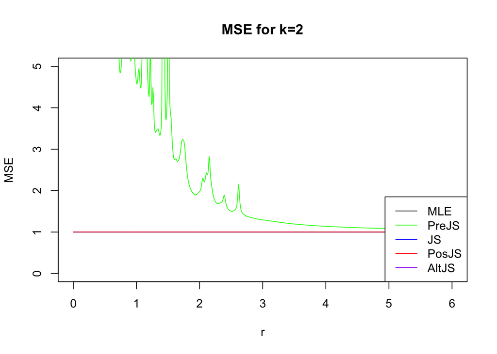

As expected the MLE has constant loss of ca. $1$. Loss is not $k$ in this case as the given loss function scales MSE loss by $\frac{1}{k}$. Similarly, the JS and the PosJS are equal to the MLE in this setting as their degrees of freedom correction $\frac{(k - 2)/k}{\overline{X^2}}$ makes the shrinkage term disappear for $k =2$. Finally, the PreJS and ALtJS estimators perform poorly. The PreJS would not be expected to perform well as it doesn’t shrink optimally and therefore in low dimensions introduces too much bias relative to the gains in variance reduction, increasing overall risk. However, as the norm $r$ of the parameter $\theta$ increases, the PreJS estimator approaches the MLE from above. This is because $\overline{X^2}$ becomes large for higher parameter vector norms, hence the PreJS skrinkage term $1 -\frac{1}{\overline{X^2}}$ tends to $1$. Intuitively, shrinkage is decreased because large $\overline{X^2}$ imply $\theta$ is most likely not close to $0$, so shrinking in this context would increase bias and MSE. Finally, the ALtJS loss is large as the shrinkage term, $1 - \frac{(k - 3)/k}{s^{2}_{X}}$, becomes larger than $1$ due to a double negative when $k=2$. Furthermore, $s^{2}_{X}$ can be very small when the two entries (because $k=2$) of $x = \theta + \epsilon$ happen to be close. If this is the case, the shrinkage term can become a very large magnifying term. This means ALtJS estimator values will potentially be much larger than MLE values, which are simply $\textbf{}X$, leading to larger scaled MSE losses for AltJS. However, the magnitude of the average losses here, seen in the first rows of the data frame “avg_loss”, seem extreme even when expecting large losses. This is the first sign of a problem with the AltJS estimator in my code which I alluded to in the description of the coding approach. To summarise, the MLE dominates for all norms $r$ in the setting where $k=2$.

```
##   k    r      MLE     PreJS       JS    PosJS        AltJS
## 1 2 0.00 1.001001  9.888626 1.001001 1.001001 1.206464e+13
## 2 2 0.01 1.001001  8.889384 1.001001 1.001001 1.179608e+13
## 3 2 0.02 1.001001 10.618034 1.001001 1.001001 1.153091e+13
## 4 2 0.03 1.001001 11.419472 1.001001 1.001001 1.126914e+13
## 5 2 0.04 1.001001 19.914291 1.001001 1.001001 1.101077e+13
## 6 2 0.05 1.001001  8.186189 1.001001 1.001001 1.075579e+13
```

### k = 3

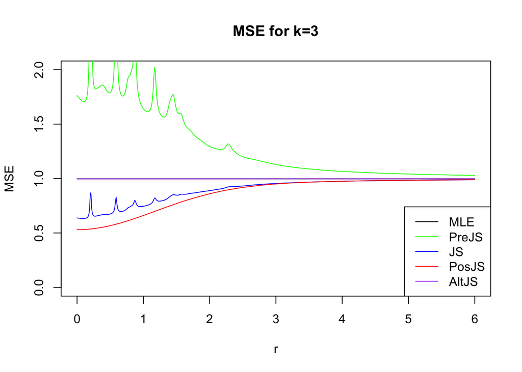

Again, the MLE has constant scaled MSE loss of ca. $1$. As expected, the JS estimator dominates the MLE apart from some jitters for low norms r of the parameter vector where the shrinkage factor is negative because $\overline{X^2}$ is small for small values of $r$ such that $\overline{X^2} < \frac{k - 2}{2}$, or equivalently $\sum_{i}{X_{i}^2} < k - 2$. The smooth line of the PosJS estimator, which excludes the possibility of a negative shrinkage factor, confirms this observation. Intuitively, both estimators approach the scaled MLE loss from below as $r$ increases for the same reasons that the PreJS approaches the scaled MLE loss from above: the trade-off between bias and variance becomes tilted toward minimising bias as the data indicates through larger $\overline{X^2}$ that $\theta$ is far away from $0$ which results in little shrinkage. Next, the PreJS performs better than in the case where $k=2$, featuring less extreme values for low norms $r$ and a smoother approach to the MLE from above. The same intuition applies as before. It is interesting to note that the spikes in the JS and PreJS coincide albeit with stronger peaks in the latter. Here, the AltJs is equal to the MLE as expected because its degrees of freedom correction makes the shrinkage term disappear for $k=3$. To summarise, the PosJS estimator dominates for all norms $r$ in the setting where $k=3$.

```
##     k    r       MLE    PreJS        JS     PosJS     AltJS
## 602 3 0.00 0.9973797 1.763540 0.6380642 0.5306232 0.9973797
## 603 3 0.01 0.9973797 1.756557 0.6372982 0.5306291 0.9973797
## 604 3 0.02 0.9973797 1.749065 0.6365033 0.5306660 0.9973797
## 605 3 0.03 0.9973797 1.741308 0.6357060 0.5307336 0.9973797
## 606 3 0.04 0.9973797 1.733767 0.6349595 0.5308321 0.9973797
## 607 3 0.05 0.9973797 1.726890 0.6343127 0.5309616 0.9973797
```

### k = 10

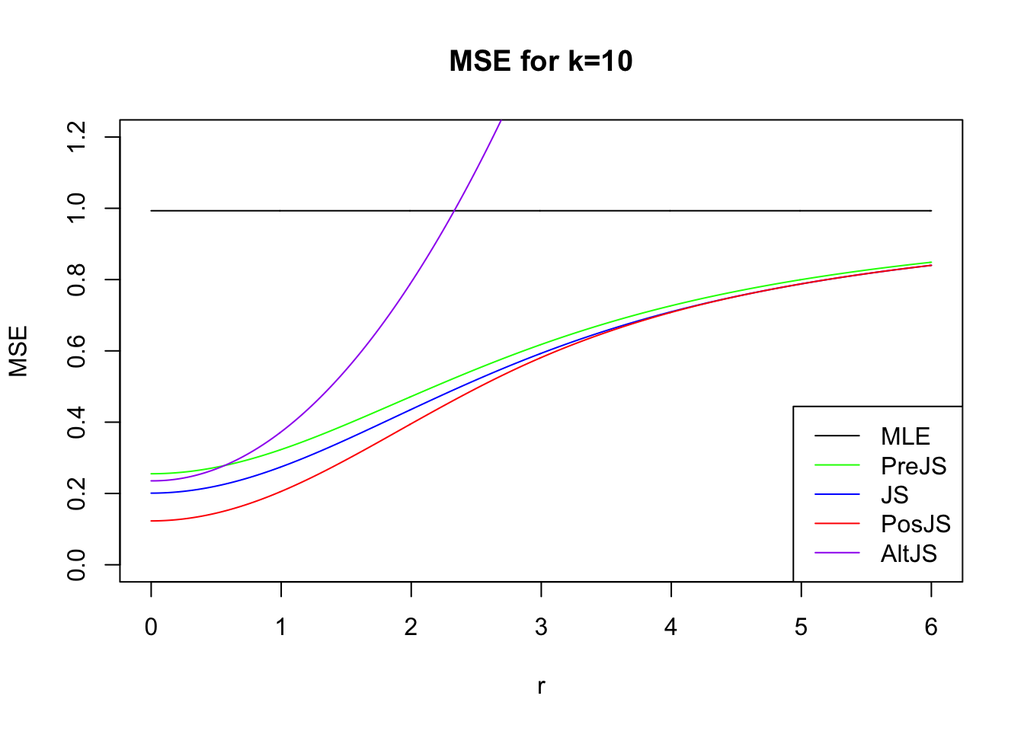

As before the MLE has constant scaled MSE loss of ca. $1$. As anticipated, PreJs, JS and PosJs all dominate the MLE as in this high-dimensional setting the trade-off between variance and bias induced by these shrinkage estimators becomes optimal irrespective of the true value of $\theta$. The PreJs is dominated by JS because the latter employs an optimal shrinkage factor. In turn, the JS is dominated by the PosJS because the latter truncates undesirable negative shrinkage factors. The only obvious issue is the AltJS. I contemplated whether the derivation of the AltJS via an intercept regression, potentially limiting its applicability might be the culprit here but that seems unlikely as no intercept is required to calculate its shrinkage factor. Furthermore, as the ALtJS features an optimal shrinkage factor, I would expect it’s shape to be similar to the other estimators and to perform about as well as the JS estimator. However, in this graph, the strictly rising curve seems reminiscent more of a constant shrinkage factor, one that does not depend on the data, such as $\lambda \bf{X}$ seen in class. Clearly, $s^{2}_{X}$ does depend on the data, though, so something is definitely off. I double checked my coding expressions for the AltJS estimator as well as the loss function many times and still did not find the mistake. As the results for the other estimators make sense it must be in some way due to the clumsy aggregation of populating an empty data frame I performed. In conclusion, this graph shows the superiority of shrinkage estimators for higher dimensional estimation problems such as supervised machine learning. In particular, among the correctly coded estimators, the PosJs seems to be the supreme choice validating its frequent use in practice.

```
##       k    r       MLE     PreJS        JS     PosJS     AltJS
## 1203 10 0.00 0.9931357 0.2553184 0.2009327 0.1229904 0.2354504
## 1204 10 0.01 0.9931357 0.2553278 0.2009462 0.1230060 0.2354310
## 1205 10 0.02 0.9931357 0.2553517 0.2009755 0.1230391 0.2354399
## 1206 10 0.03 0.9931357 0.2553904 0.2010208 0.1230898 0.2354769
## 1207 10 0.04 0.9931357 0.2554437 0.2010819 0.1231580 0.2355422
## 1208 10 0.05 0.9931357 0.2555117 0.2011589 0.1232438 0.2356356
```

# Problem 2

Taking a step back before diving into the details: Problem 2 extends the discussion of the estimation of means/single points in Problem 1 to the estimation of functions using Gaussian process priors. We build a routine using a Gaussian process prior to optimally allocate some treatment based on a set of covariates. More specifically, we implement a particular Gaussian process prior to estimate the conditional expectation of potential outcomes given covariates. We use two different estimation procedures, Bayesian optimal estimation and difference-in-means estimation, to arrive at expressions for a risk function. The risk function in this case is the (expected) mean squared error (MSE). The optimal treatment allocation to be chosen is the one that minimises MSE. To find an optimal allocation, we then generate random treatment assignments and evaluate the MSE for each.

The discussion of the second problem will be structured along the order of tasks in the exercise description. First, I will explain the procedure to arrive at the R function taking in a covariate matrix and a vector of treatment assignments to return the expected MSE for either Bayes’ optimal estimator or the difference-in-means estimator. Second, I will explain code and theory for the re-randomisation procedure and apply the code to the simple example from Kasy (2016). Finally, I will apply the re-randomisation procedure for both Bayes’ optimal estimation and for difference-in-means estimation to a subset of covariate data from the seminal paper on the short-run effects of Conditional Cash Transfers (CCTs) by Gertler, Martinez, and Marta Rubio-Codina (2012). The structure is thus as follows:

1. EMSE Function
2. Re-randomisation procedure
3. Application to real data

After some problems with my coding approach in Problem 1, I decided on a object-based approach for this part of the Problem Set.

## 1. EMSE Function

I closely followed the descriptions in Kasy (2016) page 10 for Bayes’ optimal estimation and pages 10 and 11 for difference-in-means estimation. Beginning with Bayes’ optimal estimation, I start by implementing the function for the covariance kernel as given in the exercise. I take as input covariate values and their actual treatment status $(d_{i}, d_{j})$:

$$C((x_i, d_i), (x_j, d_j)) = 10 \cdot \sigma^2 \cdot exp(-(||x_i - x_j||^2-(d_i-d_j)^2) / 10)$$

or in code:

```r
C_ij <- function(C_ij_xi, C_ij_di, C_ij_xj, C_ij_dj){
  return(10 * exp(-(sqrt(sum((C_ij_xi - C_ij_xj)^2))^2 - (C_ij_di - C_ij_dj)^2) / 10))
}
```

This is a direct implementation of the covariance kernel given in the exercise where the variance of the covariates $\sigma^2$ is standardised to $1$ as assumed in the exercise. This is accurate as we will later feed the functions with normalised covariates. Also, the length scale parameter $l=10$ is as given. Note as an aside that to avoid (unlikely) problems with “variable defined outside of function scope”-errors, I use the naming convention of prefixing a function’s inputs by the function’s name as in “C_ij_xi” for the function’s input “xi”. Next, I code 3 R functions for the $n \times n$ prior variance matrix $C$, consisting of elements $C_{ij}$ shown above, and the $n \times 1$ vector $\overline{C}$ coded via a supporting R function that calculates each element
$$\overline{C_i} = \frac{1}{n} \sum_{j}[C((X_i, d_i), (X_j, 1) - C((X_i, d_i), (X_j, 0))]$$
The R functions for $C$ and $\overline{C}$, are the two major objects for the Bayesian estimation procedure. Each takes as input an $n \times k$ matrix of covariates $X$ and an $n \times 1$ vector $D$ of $0$ and $1$ indicating treatment status for each observation $i$. (Code omitted for legibility.) Note that in constructing these objects we are working with the rows of $X$, i.e. with $n$ observations not $k$ covariates. For example, we would work with age and income of individual $i$, not with age of all individuals.

As to difference-in-means estimation, I start by implementing the function for the covariance kernel as given in the exercise taking as input covariate values and some assigned treatment status $(d^1, d^2)$, not the actual one as before:

$$C((x_i, d_1), (x_j, d_2)) = 10 \cdot \sigma^2 \cdot exp(-(||x_i - x_j||^2-(d_1-d_2)^2) / 10)$$
or in code:

```r
C_d1d2_ij <- function(C_d1d2_ij_xi, C_d1d2_ij_d1, C_d1d2_ij_xj, C_d1d2_ij_d2){
  return(10 * exp(-(sqrt(sum((C_d1d2_ij_xi - C_d1d2_ij_xj)^2))^2 - (C_d1d2_ij_d1 - C_d1d2_ij_d2)^2) / 10))
}
```

Apart from the difference in treatment status inputs, the function is the same as before for the same reasons, e.g. no $\sigma^2$ due to standardisation and length scale parameter $l=10$. Consequently, I create 2 functions to calculate the $2n \times 2n$ matrix $\tilde{C}$. These are the actual function and one support function to calculate each of the four $n \times n$ matrix elements of $\tilde{C}$ covering all four possible combinations of pairs of treatment status. (Code omitted for legibility.)

In the next step, we can finally write the function for the EMSE:

```r
EMSE <- function(covariates, treat_ind, Bayes=TRUE) {
  n <- length(treat_ind)
  n_1 <- sum(treat_ind)
  n_0 <- n - n_1
  identity_mat <- diag(n)

  # normalise covariates by column k
  covariates <- sweep(sweep(covariates, 2, colMeans(covariates)), 2, apply(covariates, 2, sd), FUN = '/')

  if (Bayes) {
    C_bar <- C_bar(covariates, treat_ind)
    C <- C_matrix(covariates, treat_ind)
    Bayes_MSE <- - t(C_bar) %*% solve(C + identity_mat) %*% C_bar
    return(Bayes_MSE)
  } else {
    C_tilda <- C_tilda(covariates)
    var_diff_est <- 1 / n_1 + 1 / n_0
    w_1 <- (1 / n_1) * treat_ind - rep(1 / n, n)
    w_0 <- -(1 / n_0) * (1 - treat_ind) + rep(1 / n, n)
    w <- c(w_1, w_0)
    var_bias2 <- t(w) %*% C_tilda %*% w
    Diff_MSE <- var_diff_est + var_bias2
    return(Diff_MSE)
  }
}
```

The function takes as input a, not-yet normalised, $n \times k$ matrix of covariates, an $n \times 1$ vector of treatment indicators and a Boolean for whether to use the Bayesian or the difference-in-means procedure. It then calculates all the relevant dimensions $n, n_{0}, n_{1}$ and normalises the covariates by subtracting their mean and dividing by their standard deviation. Note that this is done by column, e.g. take age observations for all individuals $i$, then subtract the mean age and divide by the standard deviation of age. The function proceeds based on which estimation procedure was selected. For Bayes’ optimal estimation, we use the R functions from before to arrive at the vector $\overline{C}$ and the prior variance matrix $C$. These are then used in the expression for the MSE:
$$MSE_{Bayes'}(d_1,...,d_n) = Var(\beta|X) - \overline{C}' \cdot(C + \sigma^2I)^{-1} \cdot \overline{C}$$
We ignore the $Var(\beta|X)$ term as it is unchanged by the treatment selection $(d_1,...,d_n)$ so can be ignored for the sake of optimisation in the next step. Ignoring it means, however, that our results for the Bayes’ MSE will be off by this constant. Furthermore, we drop $\sigma^2$ as it is standardised to $1$. For difference-in-means estimation, we again calculate the relevant matrix object, this time $\tilde{C}$, as well as weights $(w_0, w_1)$ in $w$ as given on page 11 in Kasy (2016). These are then plugged into the expression for the MSE:
$$MSE_{DiM}(d_1,...,d_n) = \sigma^2 \cdot \left[ \frac{1}{n_0}+ \frac{1}{n_1} \right] + (w' \cdot \tilde{\mu})^2 + w' \cdot \tilde{C} \cdot w$$
Note that up to here all expressions involving the mean $\mu$ are ignored as we are working with a Gaussian process prior with mean 0. So, here again, the term in the MSE involving $\mu$ drops out as does $\sigma^2$ for the same reason as before. Hence, the function sums the variance of the estimator (first term) and the expected squared bias which here only consists of the prior variance of the bias (last term). Next, I turn to the re-randomisation procedure.

## 2. Re-randomisation procedure

Re-randomisation requires 2 R functions. The first generates random treatment assignments based on the sample size $n$ and the number of treated observations $n_1$. (Code omitted for legibility.) The second one implements the minimisation. The function takes as input the matrix of covariates, the number of randomisations and a Boolean to determine which of the two estimation procedures to use. We deduce the sample size $n$ from the covariate vector given and set the number of observations to be treated $n_1$ to half the sample. Then we generate random samples using the R function from before and calculate the EMSE for each. Finally, we pick the treatment allocation with the minimal MSE among the randomly sampled treatment allocations. We return that allocation.

```r
minMSE <- function(covariates, randomisations, Bayes=TRUE) {
  n <- nrow(covariates)
  n_1 <- floor(n / 2)

  random_treat_inds <- sapply(1:randomisations, function(i) random_treat_ind(n, n_1))

  random_EMSEs <- sapply(1:randomisations,
                         function(i) EMSE(covariates, random_treat_inds[,i], Bayes))
  optimal_treat_MSE <- random_EMSEs[which.min(random_EMSEs)]
  optimal_treat <- random_treat_inds[,which.min(random_EMSEs)]
  return(optimal_treat)
}
```

To show the code in action, we consider the example from Kasy (2016). We have $X = (0,1,2,3)$ and use the difference-in-means estimation procedure yielding:

```
## [1] 0 1 1 0
```

This is also the treatment allocation that minimises MSE in Kasy (2016). When using Bayes’ optimal estimation, we obtain a different treatment allocation:

```
## [1] 1 1 0 0
```

While it is not guaranteed that the two estimation procedures will yield the same result, it seems odd that the Bayesian approach would provide a treatment assignment where information on the covariates is ignored. In this allocation above, the treatment group has systematically lower (or higher) values of covariates depending on whether the method returns $(1,1,0,0)$ or its complement. The problem in the implementation of the procedure here may lie in the creation of $\overline{C}$. Specifically, coded as it is $\overline{C}$ contains some negative elements. This is not completely unexpected as the expression for $\overline{C_i}$ does consist of a sum of differences. However, Kasy’s code implementation of his 2016 paper calculates $\overline{C}$ as the column means of $C$. This would preclude negative entries as the covariance kernel we use never returns negative values. To use Kasy’s approach here we need to adjust for the difference in covariance kernels used in the paper and here. In particular, we calculate $\overline{C}$ as the column means of $C$ and then divide by the scale factor $l = 10$ which pre-multiplies our covariance kernel. Doing this approximately yields the absolute value of $\overline{C}$ as coded before. Applying this method for calculating $\overline{C}$ to the same example from before, we do recover treatment assignments that are more probably optimal given covariates:

```
## [1] 0 1 1 0
```

Also the EMSE of the Bayesian “column means of $C$”-approach for one of the optimal treatment assignments, i.e. $(1,0,0,1)$ or its complement, seems more reasonable:

```
##          [,1]        [,2]
## [1,] 5.938827 -0.08936688
```

Recall that a negative MSE can occur because the constant $Var(\beta|X)$ is not required for the optimisation and has been omitted from the expression for the MSE. The actual MSE would be positive. Overall, these results seem more reasonable but I am not certain as to the theoretical underpinnings justifying the calculation of $\overline{C}$ as the vector of column means of $C$. There is no explicit mention of this relation in the Kasy (2016) paper itself, only in the accompanying code. The results from this example could be seen as evidence that it holds, albeit not as proof. It also supports the hypothesis that the issue lies in some elements of $\overline{C}$ being negative.

## 3. Application

Finally, I apply the above procedures to real world data. I use a very small subset of covariate data from the Gertler, Martinez, and Marta Rubio-Codi (2012) paper on the short-run effects of Conditional Cash Transfers (CCTs) in Mexico’s Progresa programme. The full data set is more than 100mb large and accessible via https://www.aeaweb.org/articles?id=10.1257/app.4.1.164. I restrict my attention to the household level covariates age, education level and ethnicity of the first 100 observations. The top few lines fo the data look as follows:

```
##      age_hh  educ_hh ethnicity_hh
## [1,]     59 2.880149            0
## [2,]     60 2.880149            0
## [3,]     60 2.880149            0
## [4,]     61 2.880149            0
## [5,]     60 0.000000            0
## [6,]     59 2.880149            0
```

I run 100 randomisations for (1) the difference-in-means estimation, (2) Bayes’ estimation using the original, likely erroneous, method of calculating $\overline{C}$ and (3) Bayes’ estimation calculating $\overline{C}$ as the column means of $C$. The methods propose the following, respective treatment assignments:

```
##   [1] 0 1 1 0 0 0 1 1 1 0 0 1 1 0 1 1 0 0 0 1 1 0 0 1 0 1 0 1 1 1 0 0 1 0 1 0 1
##  [38] 1 1 1 0 0 1 1 1 1 1 0 0 1 0 1 0 0 1 0 1 1 0 0 1 1 0 0 0 0 0 0 1 1 1 0 1 1
##  [75] 0 1 1 0 0 0 0 1 0 0 0 1 0 1 1 1 0 0 0 1 1 0 0 1 0 1
```

```
##   [1] 1 0 0 0 0 1 1 1 0 0 0 1 1 1 1 1 0 0 1 1 1 1 1 1 0 0 0 1 1 1 1 1 1 0 1 1 0
##  [38] 0 0 1 0 0 1 0 0 0 0 0 0 1 1 1 1 0 1 0 0 0 0 0 1 0 0 0 1 0 1 1 1 0 1 1 1 1
##  [75] 1 1 1 0 0 1 0 1 1 0 0 0 1 0 1 0 0 1 0 1 1 0 0 0 0 0
```

```
##   [1] 1 1 0 0 0 0 1 0 1 0 0 1 1 0 1 1 0 1 1 0 1 0 1 0 0 1 1 1 0 0 0 0 0 1 0 1 1
##  [38] 1 1 0 0 0 1 0 0 0 0 0 0 1 0 1 0 1 1 1 1 0 0 0 1 1 1 0 0 0 1 1 0 1 1 1 0 1
##  [75] 0 0 1 1 1 0 0 1 0 1 1 0 0 1 1 0 1 1 1 1 0 0 1 1 0 0
```

Noteworthy, is that all methods yield a different treatment allocation. The covariate set is too large, however, to draw any conclusions as to the reasonableness of the treatment assignments. Next, I look at only 4 hard-coded observations from the sample before:

```
##      [,1]     [,2] [,3]
## [1,]   59 2.880149    0
## [2,]   60 2.880149    0
## [3,]   50 0.000000    0
## [4,]   25 3.000000    1
```

I do this just in case there are problems getting the data and also to recreate some comparability between the allocations suggested by the different estimation approaches. Randomising 10 times, the three methods applied in the same order as before yield:

```
## [1] 1 0 1 0
```

```
## [1] 0 0 1 1
```

```
## [1] 0 1 0 1
```

Difference-in-means estimation and Bayes’ estimation calculating $\overline{C}$ as the column means of $C$ return the same (or complementary) treatment assignment while Bayes’ estimation using the original method of calculating $\overline{C}$ returns a different treatment assignment. Judging the treatment assignments definitively is not possible in such a multidimensional example but given the previous considerations, I would trust the treatment assignments returned by the former two. With this we have created different procedures for optimally allocating treatment based on a set of covariates. For larger data sets, larger numbers of randomisations may be required to increase confidence in the optimality of the proposed treatment allocation.